# Activity Monitoring EDA

Alf Sanchez

This is a submission of the first course project for the course, Reproducible Research. The assignment makes use of data from a personal activity monitoring device. This device collects data at 5 minute intervals through out the day. The data consists of two months of data from an anonymous individual collected during the months of October and November, 2012 and include the number of steps taken in 5 minute intervals each day.

Below are the results:

```r
## Loading and preprocessing the data

library(plyr)
library(reshape2)
library(lattice)

# Read in the activity.csv dataset. NA denotes missing values

activitydata  <- read.csv("activity.csv", na.strings="NA", header=TRUE)
head(activitydata) # check first few rows
```

```
##   steps       date interval
## 1    NA 2012-10-01        0
## 2    NA 2012-10-01        5
## 3    NA 2012-10-01       10
## 4    NA 2012-10-01       15
## 5    NA 2012-10-01       20
## 6    NA 2012-10-01       25
```

```r
attach(activitydata)
summarizeddata <- aggregate(activitydata,by=list(interval),FUN=mean,na.rm=TRUE)[c(2,4)]
head(summarizeddata) # check first few rows
```

```
##       steps interval
## 1 1.7169811        0
## 2 0.3396226        5
## 3 0.1320755       10
## 4 0.1509434       15
## 5 0.0754717       20
## 6 2.0943396       25
```

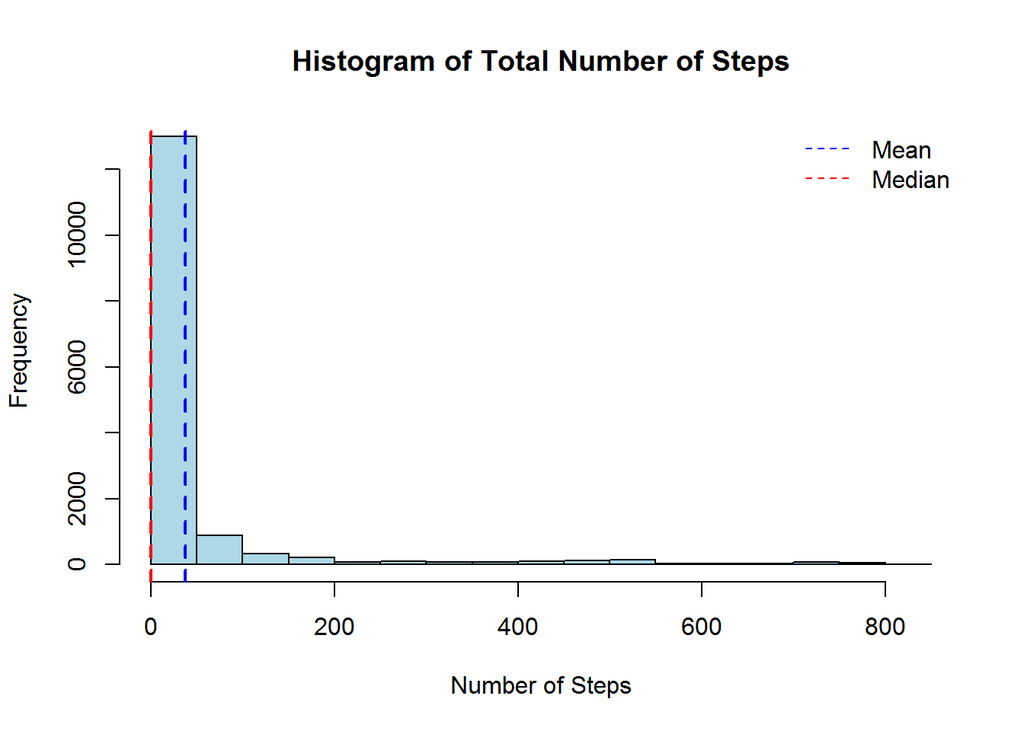

```r
# Create a histogram of the total number of steps taken each day
hist(activitydata$steps,col="Light blue", main="Histogram of Total Number of Steps", xlab="Number of Steps")
abline(v=mean(activitydata$steps,na.rm=TRUE),col="Blue",lwd=2, lty=2)
abline(v=median(activitydata$steps,na.rm=TRUE),col="Red",lwd=2, lty=2)
legend("topright",lty=c(2,2),lwd=c(1,1),col=c("Blue","Red"),bty="n",legend=c("Mean","Median"))
```

```r
#Calculate and report the mean and median total number of steps taken per day
mean(activitydata$steps,na.rm=TRUE) # Show the value of the mean (blue dashed line)
```

```
## [1] 37.3826
```

```r
median(activitydata$steps,na.rm=TRUE) # Show the value of the median (red dashed line)
```

```
## [1] 0
```

## What is the average daily activity pattern?

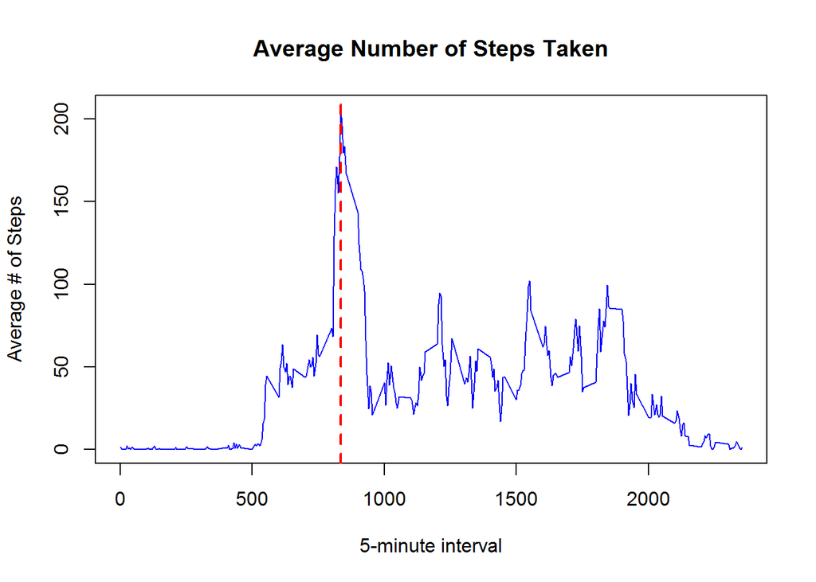

```r
# Make a time series plot (i.e. type = "l") of the 5-minute interval (x-axis) and the average number of steps taken,
# averaged across all days (y-axis)
plot(summarizeddata$interval,summarizeddata$steps,type="l",col="Blue",main="Average Number of Steps Taken", xlab="5-minute interval", ylab="Average # of Steps")
abline(v=summarizeddata[which.max(summarizeddata$steps),2],col="Red",lwd=2, lty=2)
```

```r
#Which 5-minute interval, on average across all the days in the dataset, contains the maximum number of steps?
max(summarizeddata$steps) # Show maximum average number of steps
```

```
## [1] 206.1698
```

```r
summarizeddata[which.max(summarizeddata$steps),2] # Show the 5-minute interval yielding the maximum
```

```
## [1] 835
```

## Imputing missing values

Note that there are a number of days/intervals where there are missing values (coded as NA). The presence of missing days may introduce bias into some calculations or summaries of the data.

```r
# Calculate and report the total number of missing values in the dataset (i.e. the total number of rows with NAs)
NROW(activitydata)-NROW(na.omit(activitydata)) # Show number of rows with NA
```

```
## [1] 2304
```

Devise a strategy for filling in all of the missing values in the dataset. The strategy does not need to be sophisticated. For example, you could use the mean/median for that day, or the mean for that 5-minute interval, etc.

```r
# This step imputes the average number of steps of the corresponding 5-minute interval for missing data

imputedata <- summarizeddata
colnames(imputedata) <- c("avesteps","interval")

mergeddata <- mutate(merge(activitydata,imputedata,by="interval"),newsteps=0)

for (i in 1:length(mergeddata$steps)){
    if (is.na(mergeddata$steps[[i]])) {mergeddata$newsteps[[i]]=mergeddata$avesteps[[i]]}
    else {mergeddata$newsteps[[i]]=mergeddata$steps[[i]]}
    }

# Create a new dataset that is equal to the original dataset but with the missing data filled in.

newactivitydata <- mergeddata[c(1,3,5)]
colnames(newactivitydata) <- c("interval","date","steps") # Retain original header names
head(newactivitydata)
```

```
##   interval       date    steps
## 1        0 2012-10-01 1.716981
## 2        0 2012-11-23 0.000000
## 3        0 2012-10-28 0.000000
## 4        0 2012-11-06 0.000000
## 5        0 2012-11-24 0.000000
## 6        0 2012-11-15 0.000000
```

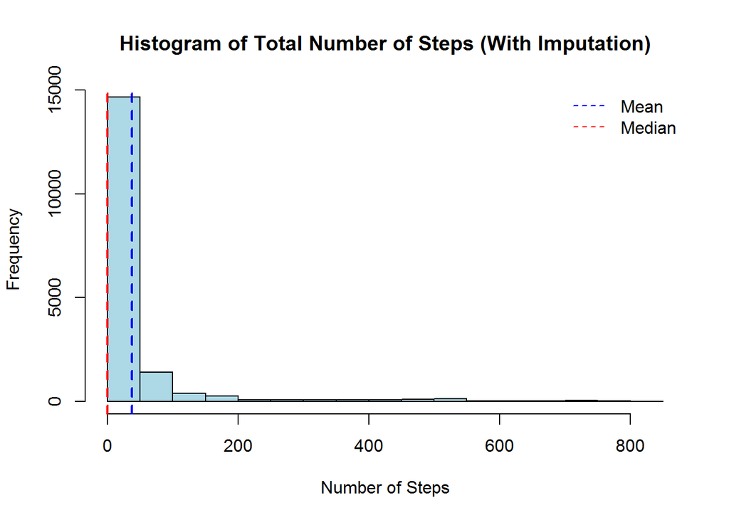

```r
# Make a histogram of the total number of steps taken each day

hist(newactivitydata$steps,col="Light blue", main="Histogram of Total Number of Steps (With Imputation)", xlab="Number of Steps")
abline(v=mean(newactivitydata$steps,na.rm=TRUE),col="Blue",lwd=2, lty=2)
abline(v=median(newactivitydata$steps,na.rm=TRUE),col="Red",lwd=2, lty=2)
legend("topright",lty=c(2,2),lwd=c(1,1),col=c("Blue","Red"),bty="n",legend=c("Mean","Median"))
```

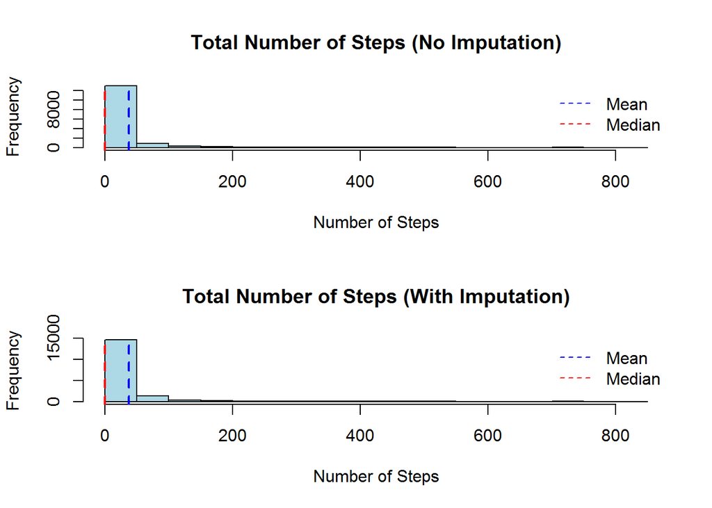

```r
# Comparing with and without imputation


par(mfrow=c(2,1))

hist(activitydata$steps,col="Light blue", main="Total Number of Steps (No Imputation)", xlab="Number of Steps")
abline(v=mean(activitydata$steps,na.rm=TRUE),col="Blue",lwd=2, lty=2)
abline(v=median(activitydata$steps,na.rm=TRUE),col="Red",lwd=2, lty=2)
legend("topright",lty=c(2,2),lwd=c(1,1),col=c("Blue","Red"),bty="n",legend=c("Mean","Median"))

hist(newactivitydata$steps,col="Light blue", main="Total Number of Steps (With Imputation)", xlab="Number of Steps")
abline(v=mean(newactivitydata$steps,na.rm=TRUE),col="Blue",lwd=2, lty=2)
abline(v=median(newactivitydata$steps,na.rm=TRUE),col="Red",lwd=2, lty=2)
legend("topright",lty=c(2,2),lwd=c(1,1),col=c("Blue","Red"),bty="n",legend=c("Mean","Median"))
```

```r
# Calculate and report the mean and median total number of steps taken per day

mean(newactivitydata$steps,na.rm=TRUE) # Show the value of the mean (blue dashed line)
```

```
## [1] 37.3826
```

```r
median(newactivitydata$steps,na.rm=TRUE) # Show the value of the median (red dashed line)
```

```
## [1] 0
```